# ComplexData_Wrangling

Kaushik Surej

2026-08-19

# Load the set of packages you want

```r
 library(tidyverse)
```

## Tidying Data: Creation of Tibbles

```r
table1 %>%
  mutate(rate = cases / population * 10000)
```

```
## # A tibble: 6 × 5
##   country      year  cases population  rate
##   <chr>       <dbl>  <dbl>      <dbl> <dbl>
## 1 Afghanistan  1999    745   19987071 0.373
## 2 Afghanistan  2000   2666   20595360 1.29
## 3 Brazil       1999  37737  172006362 2.19
## 4 Brazil       2000  80488  174504898 4.61
## 5 China        1999 212258 1272915272 1.67
## 6 China        2000 213766 1280428583 1.67
```

```r
# Title of the table: Table 1
```

- Based on the previously constructed table, aptly named table 1, we see that the work of a table helps with the filtering and summarizing of data, along with the structuring of functions such as group or color can be sorted
- A dataframe of this type can help us use functions like group or color in ggplot 2.

```r
# Compute cases per year
table1 %>%
  count(year, wt = cases)
```

```
## # A tibble: 2 × 2
##    year      n
##   <dbl>  <dbl>
## 1  1999 250740
## 2  2000 296920
```

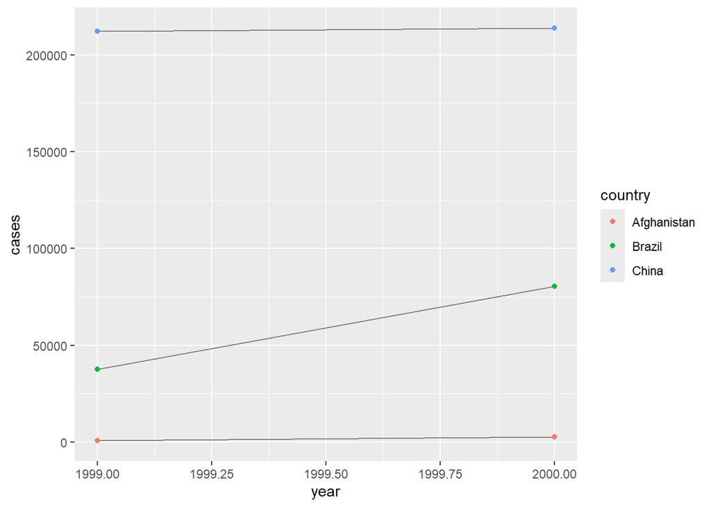

```r
# Trying to visualize these changes over time
ggplot(table1, aes(year, cases)) +
  geom_line(aes(group = country), colour = "grey50") +
  geom_point(aes(colour = country))
```

# Pivoting the data to make it even more tidier

## STEP 1:

Tidying of data is a process where you as the programmer will have to understand what each variable and observation actually refers to

## STEP 2:

Resolving the issues that you find within the dataset and these issues can can be of two major types:

- One variable spread across multiple columns
- One observation scattered across multiple rows
1. This is where the application of “pivoting” our data comes in handy.
2. For tidying the data that we have in our hands, using of two different functions such as “tidyr: pivot_longer()” and “tidyr:pivot_widen()” will help us to lengthen and widen our data respectively.

# Lengthening of Datasets

Function used; tidyr:pivot_longer() Grouping function in play: facet_wrap()

3. The pivot_longer() functions in such a way that it splits the dataset in hand by columns and re-formats into observations as rows, columns as variables and values as cell entries

```r
billboard
```

```
## # A tibble: 317 × 79
##    artist     track date.entered   wk1   wk2   wk3   wk4   wk5   wk6   wk7   wk8
##    <chr>      <chr> <date>       <dbl> <dbl> <dbl> <dbl> <dbl> <dbl> <dbl> <dbl>
##  1 2 Pac      Baby… 2000-02-26      87    82    72    77    87    94    99    NA
##  2 2Ge+her    The … 2000-09-02      91    87    92    NA    NA    NA    NA    NA
##  3 3 Doors D… Kryp… 2000-04-08      81    70    68    67    66    57    54    53
##  4 3 Doors D… Loser 2000-10-21      76    76    72    69    67    65    55    59
##  5 504 Boyz   Wobb… 2000-04-15      57    34    25    17    17    31    36    49
##  6 98^0       Give… 2000-08-19      51    39    34    26    26    19     2     2
##  7 A*Teens    Danc… 2000-07-08      97    97    96    95   100    NA    NA    NA
##  8 Aaliyah    I Do… 2000-01-29      84    62    51    41    38    35    35    38
##  9 Aaliyah    Try … 2000-03-18      59    53    38    28    21    18    16    14
## 10 Adams, Yo… Open… 2000-08-26      76    76    74    69    68    67    61    58
## # ℹ 307 more rows
## # ℹ 68 more variables: wk9 <dbl>, wk10 <dbl>, wk11 <dbl>, wk12 <dbl>,
## #   wk13 <dbl>, wk14 <dbl>, wk15 <dbl>, wk16 <dbl>, wk17 <dbl>, wk18 <dbl>,
## #   wk19 <dbl>, wk20 <dbl>, wk21 <dbl>, wk22 <dbl>, wk23 <dbl>, wk24 <dbl>,
## #   wk25 <dbl>, wk26 <dbl>, wk27 <dbl>, wk28 <dbl>, wk29 <dbl>, wk30 <dbl>,
## #   wk31 <dbl>, wk32 <dbl>, wk33 <dbl>, wk34 <dbl>, wk35 <dbl>, wk36 <dbl>,
## #   wk37 <dbl>, wk38 <dbl>, wk39 <dbl>, wk40 <dbl>, wk41 <dbl>, wk42 <dbl>, …
```

```r
# Pivoting longer applied on the billboard dataset

billboard |>
  pivot_longer(
    cols = starts_with("wk"),
    names_to = "week",
    values_to = "rank"
  )
```

```
## # A tibble: 24,092 × 5
##    artist track                   date.entered week   rank
##    <chr>  <chr>                   <date>       <chr> <dbl>
##  1 2 Pac  Baby Don't Cry (Keep... 2000-02-26   wk1      87
##  2 2 Pac  Baby Don't Cry (Keep... 2000-02-26   wk2      82
##  3 2 Pac  Baby Don't Cry (Keep... 2000-02-26   wk3      72
##  4 2 Pac  Baby Don't Cry (Keep... 2000-02-26   wk4      77
##  5 2 Pac  Baby Don't Cry (Keep... 2000-02-26   wk5      87
##  6 2 Pac  Baby Don't Cry (Keep... 2000-02-26   wk6      94
##  7 2 Pac  Baby Don't Cry (Keep... 2000-02-26   wk7      99
##  8 2 Pac  Baby Don't Cry (Keep... 2000-02-26   wk8      NA
##  9 2 Pac  Baby Don't Cry (Keep... 2000-02-26   wk9      NA
## 10 2 Pac  Baby Don't Cry (Keep... 2000-02-26   wk10     NA
## # ℹ 24,082 more rows
```

```r
# Creation of three separate arguments in the form of "cols", "starts_with('wk')" and "values_to"

billboard |>
  pivot_longer(
    cols = starts_with("wk"),
    names_to = "week",
    values_to = "rank",
    values_drop_na = TRUE
  )
```

```
## # A tibble: 5,307 × 5
##    artist  track                   date.entered week   rank
##    <chr>   <chr>                   <date>       <chr> <dbl>
##  1 2 Pac   Baby Don't Cry (Keep... 2000-02-26   wk1      87
##  2 2 Pac   Baby Don't Cry (Keep... 2000-02-26   wk2      82
##  3 2 Pac   Baby Don't Cry (Keep... 2000-02-26   wk3      72
##  4 2 Pac   Baby Don't Cry (Keep... 2000-02-26   wk4      77
##  5 2 Pac   Baby Don't Cry (Keep... 2000-02-26   wk5      87
##  6 2 Pac   Baby Don't Cry (Keep... 2000-02-26   wk6      94
##  7 2 Pac   Baby Don't Cry (Keep... 2000-02-26   wk7      99
##  8 2Ge+her The Hardest Part Of ... 2000-09-02   wk1      91
##  9 2Ge+her The Hardest Part Of ... 2000-09-02   wk2      87
## 10 2Ge+her The Hardest Part Of ... 2000-09-02   wk3      92
## # ℹ 5,297 more rows
```

4. Before we create the tibble with columns named “week” and “rank”, we see that the two coloumns are in double quotation because these are the two new variables that are yet to be made and only once we make them, will we be able to input them into our preexisting Billboards dataset.

```r
billboard |>
  pivot_longer(
    cols = starts_with("wk"),
    names_to = "week",
    values_to = "rank",
    values_drop_na = TRUE
  )
```

```
## # A tibble: 5,307 × 5
##    artist  track                   date.entered week   rank
##    <chr>   <chr>                   <date>       <chr> <dbl>
##  1 2 Pac   Baby Don't Cry (Keep... 2000-02-26   wk1      87
##  2 2 Pac   Baby Don't Cry (Keep... 2000-02-26   wk2      82
##  3 2 Pac   Baby Don't Cry (Keep... 2000-02-26   wk3      72
##  4 2 Pac   Baby Don't Cry (Keep... 2000-02-26   wk4      77
##  5 2 Pac   Baby Don't Cry (Keep... 2000-02-26   wk5      87
##  6 2 Pac   Baby Don't Cry (Keep... 2000-02-26   wk6      94
##  7 2 Pac   Baby Don't Cry (Keep... 2000-02-26   wk7      99
##  8 2Ge+her The Hardest Part Of ... 2000-09-02   wk1      91
##  9 2Ge+her The Hardest Part Of ... 2000-09-02   wk2      87
## 10 2Ge+her The Hardest Part Of ... 2000-09-02   wk3      92
## # ℹ 5,297 more rows
```

```r
df <- tribble(
  ~id,  ~bp1, ~bp2,
   "A",  100,  120,
   "B",  140,  115,
   "C",  120,  125
)
```

- The example that was run within the previous code chunk shows that a dataset named “df” was created by us.

```r
df |>
  pivot_longer(
    cols = bp1:bp2,
    names_to = "measurement",
    values_to = "value"
  )
```

```
## # A tibble: 6 × 3
##   id    measurement value
##   <chr> <chr>       <dbl>
## 1 A     bp1           100
## 2 A     bp2           120
## 3 B     bp1           140
## 4 B     bp2           115
## 5 C     bp1           120
## 6 C     bp2           125
```

22. The tibble which was created based on the line of code which was run, shows us that a dataset named “df” has been made with a real-time values in place

# Widening of Datasets

Function used: pivot_wider()

6. “pivot_wider()” as a function helps us handle a variety of observations across messy or inconsistent datasheets or datasets scattered across multiple rows.

```r
cms_patient_experience
```

```
## # A tibble: 500 × 5
##    org_pac_id org_nm                           measure_cd measure_title prf_rate
##    <chr>      <chr>                            <chr>      <chr>            <dbl>
##  1 0446157747 USC CARE MEDICAL GROUP INC       CAHPS_GRP… CAHPS for MI…       63
##  2 0446157747 USC CARE MEDICAL GROUP INC       CAHPS_GRP… CAHPS for MI…       87
##  3 0446157747 USC CARE MEDICAL GROUP INC       CAHPS_GRP… CAHPS for MI…       86
##  4 0446157747 USC CARE MEDICAL GROUP INC       CAHPS_GRP… CAHPS for MI…       57
##  5 0446157747 USC CARE MEDICAL GROUP INC       CAHPS_GRP… CAHPS for MI…       85
##  6 0446157747 USC CARE MEDICAL GROUP INC       CAHPS_GRP… CAHPS for MI…       24
##  7 0446162697 ASSOCIATION OF UNIVERSITY PHYSI… CAHPS_GRP… CAHPS for MI…       59
##  8 0446162697 ASSOCIATION OF UNIVERSITY PHYSI… CAHPS_GRP… CAHPS for MI…       85
##  9 0446162697 ASSOCIATION OF UNIVERSITY PHYSI… CAHPS_GRP… CAHPS for MI…       83
## 10 0446162697 ASSOCIATION OF UNIVERSITY PHYSI… CAHPS_GRP… CAHPS for MI…       63
## # ℹ 490 more rows
```

```r
cms_patient_experience |>
  distinct(measure_cd, measure_title)
```

```
## # A tibble: 6 × 2
##   measure_cd   measure_title
##   <chr>        <chr>
## 1 CAHPS_GRP_1  CAHPS for MIPS SSM: Getting Timely Care, Appointments, and Infor…
## 2 CAHPS_GRP_2  CAHPS for MIPS SSM: How Well Providers Communicate
## 3 CAHPS_GRP_3  CAHPS for MIPS SSM: Patient's Rating of Provider
## 4 CAHPS_GRP_5  CAHPS for MIPS SSM: Health Promotion and Education
## 5 CAHPS_GRP_8  CAHPS for MIPS SSM: Courteous and Helpful Office Staff
## 6 CAHPS_GRP_12 CAHPS for MIPS SSM: Stewardship of Patient Resources
```

```r
# Using the pivot_wider() function
cms_patient_experience |>
  pivot_wider(
    names_from = measure_cd,
    values_from = prf_rate
  )
```

```
## # A tibble: 500 × 9
##    org_pac_id org_nm           measure_title CAHPS_GRP_1 CAHPS_GRP_2 CAHPS_GRP_3
##    <chr>      <chr>            <chr>               <dbl>       <dbl>       <dbl>
##  1 0446157747 USC CARE MEDICA… CAHPS for MI…          63          NA          NA
##  2 0446157747 USC CARE MEDICA… CAHPS for MI…          NA          87          NA
##  3 0446157747 USC CARE MEDICA… CAHPS for MI…          NA          NA          86
##  4 0446157747 USC CARE MEDICA… CAHPS for MI…          NA          NA          NA
##  5 0446157747 USC CARE MEDICA… CAHPS for MI…          NA          NA          NA
##  6 0446157747 USC CARE MEDICA… CAHPS for MI…          NA          NA          NA
##  7 0446162697 ASSOCIATION OF … CAHPS for MI…          59          NA          NA
##  8 0446162697 ASSOCIATION OF … CAHPS for MI…          NA          85          NA
##  9 0446162697 ASSOCIATION OF … CAHPS for MI…          NA          NA          83
## 10 0446162697 ASSOCIATION OF … CAHPS for MI…          NA          NA          NA
## # ℹ 490 more rows
## # ℹ 3 more variables: CAHPS_GRP_5 <dbl>, CAHPS_GRP_8 <dbl>, CAHPS_GRP_12 <dbl>
```

- Even though the data looks a bit more consistent, we still have about 500 rows of data. To minimize the amount of time that is required to work with a somewhat large dataset such as this, let us reintroduce “pivot_wider()” again, to show the presence of columns that have values that are unique to each row, making it easier to identify
7. The identification of these rows can be done by looking at the name that we have given called “org”, short for “organizations”

```r
cms_patient_experience |>
  pivot_wider(
    id_cols = starts_with("org"),
    names_from = measure_cd,
    values_from = prf_rate
  )
```

```
## # A tibble: 95 × 8
##    org_pac_id org_nm CAHPS_GRP_1 CAHPS_GRP_2 CAHPS_GRP_3 CAHPS_GRP_5 CAHPS_GRP_8
##    <chr>      <chr>        <dbl>       <dbl>       <dbl>       <dbl>       <dbl>
##  1 0446157747 USC C…          63          87          86          57          85
##  2 0446162697 ASSOC…          59          85          83          63          88
##  3 0547164295 BEAVE…          49          NA          75          44          73
##  4 0749333730 CAPE …          67          84          85          65          82
##  5 0840104360 ALLIA…          66          87          87          64          87
##  6 0840109864 REX H…          73          87          84          67          91
##  7 0840513552 SCL H…          58          83          76          58          78
##  8 0941545784 GRITM…          46          86          81          54          NA
##  9 1052612785 COMMU…          65          84          80          58          87
## 10 1254237779 OUR L…          61          NA          NA          65          NA
## # ℹ 85 more rows
## # ℹ 1 more variable: CAHPS_GRP_12 <dbl>
```

- Reworking with the “df” dataset, but with the “pivot_wider()” function this time

```r
df <- tribble(
  ~id, ~measurement, ~value,
  "A",        "bp1",    100,
  "B",        "bp1",    140,
  "B",        "bp2",    115,
  "A",        "bp2",    120,
  "A",        "bp3",    105
)

df |>
  pivot_wider(
    names_from = measurement,
    values_from = value
  )
```

```
## # A tibble: 2 × 4
##   id      bp1   bp2   bp3
##   <chr> <dbl> <dbl> <dbl>
## 1 A       100   120   105
## 2 B       140   115    NA
```

```r
df |>
  distinct(measurement) |> # Creating a new column which will show the unique values of measurement
  pull()
```

```
## [1] "bp1" "bp2" "bp3"
```

```r
df |>
  select(-measurement, -value) |>
  distinct()
```

```
## # A tibble: 2 × 1
##   id
##   <chr>
## 1 A
## 2 B
```

```r
df |>
  select(-measurement, -value) |>
  distinct() |>
  mutate(x = NA, y = NA, z = NA) # Combining the results that we wanted and generating an empty dataframe with only NA values at the end of the day
```

```
## # A tibble: 2 × 4
##   id    x     y     z
##   <chr> <lgl> <lgl> <lgl>
## 1 A     NA    NA    NA
## 2 B     NA    NA    NA
```

# PIVOTING EXERCISE: Palmer Penguins Dataset

## Lengthening using pivot_longer() with facet_wrap() in play

```r
# install.packages("palmerpenguins")
 library(palmerpenguins)
## Creating a long version of the penguin dataset

penguins_long <- penguins |>
  pivot_longer(
    cols = c(bill_length_mm, bill_depth_mm, flipper_length_mm, body_mass_g),
    names_to = "measurement_type",
    values_to = "value"
  )
head(penguins_long)
```

```
## # A tibble: 6 × 6
##   species island    sex     year measurement_type   value
##   <fct>   <fct>     <fct>  <int> <chr>              <dbl>
## 1 Adelie  Torgersen male    2007 bill_length_mm      39.1
## 2 Adelie  Torgersen male    2007 bill_depth_mm       18.7
## 3 Adelie  Torgersen male    2007 flipper_length_mm  181
## 4 Adelie  Torgersen male    2007 body_mass_g       3750
## 5 Adelie  Torgersen female  2007 bill_length_mm      39.5
## 6 Adelie  Torgersen female  2007 bill_depth_mm       17.4
```

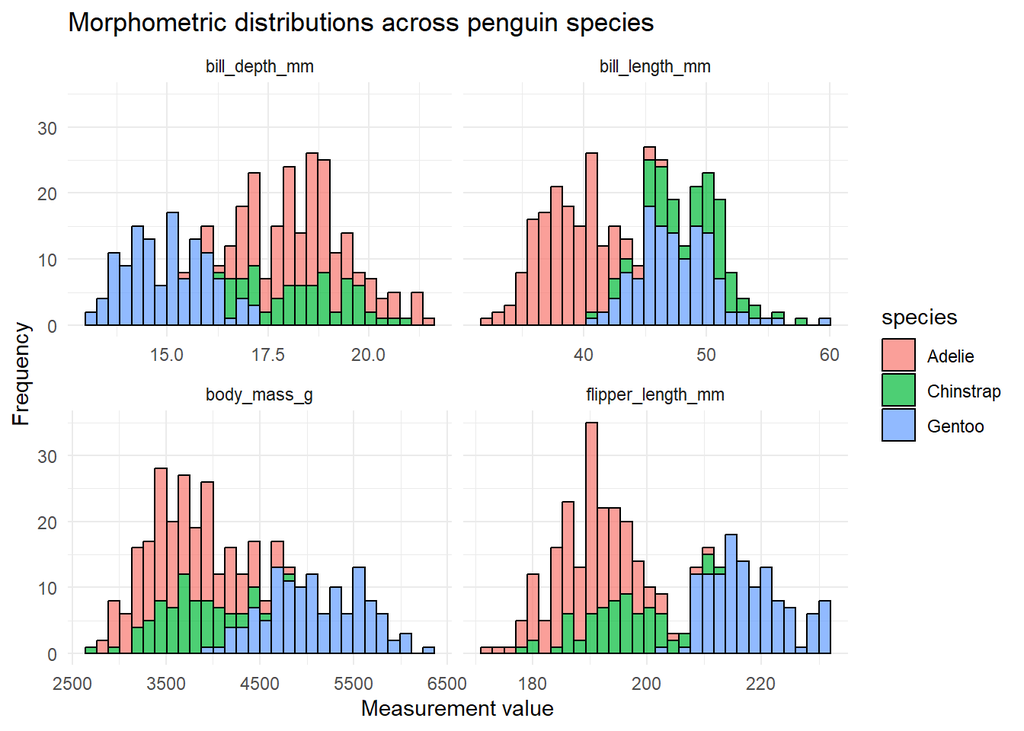

```r
## Running ggplot2 based on the 6*6 Palmer Penguin that was created
penguins_long |>
  drop_na(value) |>
  ggplot(aes(x = value, fill = species)) +
  geom_histogram(bins = 30, alpha = 0.7, colour = "black") +
  facet_wrap(~ measurement_type, scales = "free_x") +
  theme_minimal() +
  labs(
    title = "Morphometric distributions across penguin species",
    x = "Measurement value",
    y = "Frequency"
  )
```

## Widening the data using “pivot_wider()”

### Mean body mass for each species within each island calculated using “group_by()” and “summarise()”

```r
mass_summary <- penguins |>
  drop_na(body_mass_g) |>
  group_by(species, island) |>
  summarise(mean_mass = mean(body_mass_g))
```

[output not shown]

```r
head(mass_summary)
```

```
## # A tibble: 5 × 3
## # Groups:   species [3]
##   species   island    mean_mass
##   <fct>     <fct>         <dbl>
## 1 Adelie    Biscoe        3710.
## 2 Adelie    Dream         3688.
## 3 Adelie    Torgersen     3706.
## 4 Chinstrap Dream         3733.
## 5 Gentoo    Biscoe        5076.
```

```r
mass_matrix <- mass_summary |>
  pivot_wider(
    names_from = island,
    values_from = mean_mass
  )

head(mass_matrix)
```

```
## # A tibble: 3 × 4
## # Groups:   species [3]
##   species   Biscoe Dream Torgersen
##   <fct>      <dbl> <dbl>     <dbl>
## 1 Adelie     3710. 3688.     3706.
## 2 Chinstrap    NA  3733.       NA
## 3 Gentoo     5076.   NA        NA
```

# Separating and Uniting of Different Data Tables:

- Creating a new table; Lets call it “table3”

```r
table3
```

```
## # A tibble: 6 × 3
##   country      year rate
##   <chr>       <dbl> <chr>
## 1 Afghanistan  1999 745/19987071
## 2 Afghanistan  2000 2666/20595360
## 3 Brazil       1999 37737/172006362
## 4 Brazil       2000 80488/174504898
## 5 China        1999 212258/1272915272
## 6 China        2000 213766/1280428583
```

```r
table3 %>%
  separate(rate, into = c("cases", "population"))
```

```
## # A tibble: 6 × 4
##   country      year cases  population
##   <chr>       <dbl> <chr>  <chr>
## 1 Afghanistan  1999 745    19987071
## 2 Afghanistan  2000 2666   20595360
## 3 Brazil       1999 37737  172006362
## 4 Brazil       2000 80488  174504898
## 5 China        1999 212258 1272915272
## 6 China        2000 213766 1280428583
```

### Rewriting the code to pass different characters across separate arguments

```r
table3 %>%
  separate(rate, into = c("cases", "population"), sep = "/")
```

```
## # A tibble: 6 × 4
##   country      year cases  population
##   <chr>       <dbl> <chr>  <chr>
## 1 Afghanistan  1999 745    19987071
## 2 Afghanistan  2000 2666   20595360
## 3 Brazil       1999 37737  172006362
## 4 Brazil       2000 80488  174504898
## 5 China        1999 212258 1272915272
## 6 China        2000 213766 1280428583
```

```r
table3 %>%
  separate(rate, into = c("cases", "population"), convert = TRUE)
```

```
## # A tibble: 6 × 4
##   country      year  cases population
##   <chr>       <dbl>  <int>      <int>
## 1 Afghanistan  1999    745   19987071
## 2 Afghanistan  2000   2666   20595360
## 3 Brazil       1999  37737  172006362
## 4 Brazil       2000  80488  174504898
## 5 China        1999 212258 1272915272
## 6 China        2000 213766 1280428583
```

```r
table3 %>%
  separate(year, into = c("century", "year"), sep = 2) # the no. 2 signifies the last two digits of each year the case was filed
```

```
## # A tibble: 6 × 4
##   country     century year  rate
##   <chr>       <chr>   <chr> <chr>
## 1 Afghanistan 19      99    745/19987071
## 2 Afghanistan 20      00    2666/20595360
## 3 Brazil      19      99    37737/172006362
## 4 Brazil      20      00    80488/174504898
## 5 China       19      99    212258/1272915272
## 6 China       20      00    213766/1280428583
```

### Using “unite()”:

```r
## MAKING A NEW TABLE CALLED table5, uniting values such as century and year

table5 %>%
  unite(new, century, year, sep = "")
```

```
## # A tibble: 6 × 3
##   country     new   rate
##   <chr>       <chr> <chr>
## 1 Afghanistan 1999  745/19987071
## 2 Afghanistan 2000  2666/20595360
## 3 Brazil      1999  37737/172006362
## 4 Brazil      2000  80488/174504898
## 5 China       1999  212258/1272915272
## 6 China       2000  213766/1280428583
```

# Wrangling strings and dates

## Standardizing text using the “stringr” package

```r
library(tidyverse)

# Cleaning site names across Magnetic Island
# Help it follow a consistent pattern

messy_sites <- tibble(
  site_id = c(" Nelly Bay", "nelly_bay", "NELLY BAY", " Geoffrey_Bay ", "geoffrey bay")
)

clean_sites <- messy_sites |>
  mutate(
    # 1. Convert everything to lowercase
    site_clean = str_to_lower(site_id),
    # 2. Replace any spaces with underscores
    site_clean = str_replace_all(site_clean, pattern = " ", replacement = "_"),
    # 3. Trim any leading or trailing whitespace (invisible spaces at the ends)
    site_clean = str_trim(site_clean)
  )

print(clean_sites)
```

```
## # A tibble: 5 × 2
##   site_id          site_clean
##   <chr>            <chr>
## 1 " Nelly Bay"     _nelly_bay
## 2 "nelly_bay"      nelly_bay
## 3 "NELLY BAY"      nelly_bay
## 4 " Geoffrey_Bay " _geoffrey_bay_
## 5 "geoffrey bay"   geoffrey_bay
```

# Standardize time and date formats:

Package in play: “lubridate”

```r
library(lubridate)

date_1 <- dmy("25/12/2026")
date_2 <- ymd("2026-12-25")

date_1 == date_2 # Even though the date format had changed because of the running of the package "lubridate", we see that the timeline that has been mentioned remains the same
```

```
## [1] TRUE
```

```r
# A tibble of raw sensor data with a messy character timestamp
sensor_data <- tibble(
  raw_time = c("14-05-2026 08:30:00", "14-05-2026 08:45:00", "14-05-2026 09:00:00"),
  temperature = c(24.5, 24.6, 24.4)
)

# Converting character strings to true POSIXct datetime objects
sensor_clean <- sensor_data |>
  mutate(
    true_time = dmy_hms(raw_time)
  )

print(sensor_clean)
```

```
## # A tibble: 3 × 3
##   raw_time            temperature true_time
##   <chr>                     <dbl> <dttm>
## 1 14-05-2026 08:30:00        24.5 2026-05-14 08:30:00
## 2 14-05-2026 08:45:00        24.6 2026-05-14 08:45:00
## 3 14-05-2026 09:00:00        24.4 2026-05-14 09:00:00
```

# Joining Tables: Relational Data

9. Multiple tables that share a common data entry point have been known to provide several mutating joins with the help of the “dplyr” package
- Example used: A massive daily fish catch table with the only record on display being the construction of a list called “site_code”, with a smaller, separate table consisting of metadata such as the GPS coordinates and the zoning status for these site codes.

```r
# Table 1: Biological observation data
observations <- tibble(
  site_code = c("NB", "GB", "MI", "NB", "HB"),
  species = c("Trout", "Snapper", "Trout", "Cod", "Trout"),
  count = c(5, 2, 1, 3, 8)
)

# Table 2: Spatial metadata
site_metadata <- tibble(
  site_code = c("NB", "GB", "MI", "RP", "WP"),
  zone = c("Marine National Park", "Conservation Park", "Habitat Protection", "General Use", "Other Use"),
  lat = c(-19.16, -19.15, -19.14, -19.12, -19.11)
)

# Joining the metadata to the biological observation table using the "left_join()" and the "right_join()" functions
joined_data <- observations |>
  left_join(site_metadata, by = join_by(site_code))

print(joined_data)
```

```
## # A tibble: 5 × 5
##   site_code species count zone                   lat
##   <chr>     <chr>   <dbl> <chr>                <dbl>
## 1 NB        Trout       5 Marine National Park -19.2
## 2 GB        Snapper     2 Conservation Park    -19.2
## 3 MI        Trout       1 Habitat Protection   -19.1
## 4 NB        Cod         3 Marine National Park -19.2
## 5 HB        Trout       8 <NA>                  NA
```

```r
# Running an "inner_join()" function to keep only those set of rows which match across both the tables
matched_data <- observations |>
  inner_join(site_metadata, by = join_by(site_code))
glimpse(matched_data)
```

```
## Rows: 4
## Columns: 5
## $ site_code <chr> "NB", "GB", "MI", "NB"
## $ species   <chr> "Trout", "Snapper", "Trout", "Cod"
## $ count     <dbl> 5, 2, 1, 3
## $ zone      <chr> "Marine National Park", "Conservation Park", "Habitat Protec…
## $ lat       <dbl> -19.16, -19.15, -19.14, -19.16
```

```r
# The use of "anti_join()" to show the presence of rows that do not match with the once found within the metadata table
missing_context <- observations |>
  anti_join(site_metadata, by = join_by(site_code))
```

# Understanding the need to having missing values handled

- “NA” (missing data) values are a part and parcel of data science
- The occurrence of situations such as these can be due to a variety of factors which might have halted the process of data collection and sampling
- Other times, cells are left as zeroes deliberately because of various other factors such as time in play
- The other likely scenario as to why we might encounter our progress being halted due to a missing value would be the occurrence from our end, while trying to calculate the numerical we have in our hand, leading to the appraisal human biases

## Conversion of legacy errors

24. Function used: “na_if()”; This particular function provided by the “dplyr” package converts the values that we are not interested in, into NA/missing values. This makes it an extremely useful tool for the purpose of data cleaning

```r
logger_data <- tibble(
  depth_m = c(10, 20, 30, 40),
  temp_c = c(24.5, 24.1, -999, 23.5)) # -999 is a known sensor error code

## Converting the -999 error code into a true NA value
fixed_logger <- logger_data |>
  mutate(temp_c = na_if(temp_c, -999))

print(fixed_logger)
```

```
## # A tibble: 4 × 2
##   depth_m temp_c
##     <dbl>  <dbl>
## 1      10   24.5
## 2      20   24.1
## 3      30   NA
## 4      40   23.5
```

## Replacing missing values with coalesce()

11. “coalesce()” helps us figure out the specific set of NA value(s) that messes with our dataset, segregate its column and replace the NA value with a 0

```r
shark_counts <- tibble(
  site = c("Reef_A", "Reef_B", "Reef_C"),
  shark_count = c(3, NA, 5))

# Replacing NA with 0
shark_fixed <- shark_counts |>
  mutate(shark_count = coalesce(shark_count, 0))

print(shark_fixed)
```

```
## # A tibble: 3 × 2
##   site   shark_count
##   <chr>        <dbl>
## 1 Reef_A           3
## 2 Reef_B           0
## 3 Reef_C           5
```

### What is NaN (Not a Number)?

- NaN is nothing but a value within the space of programming and data analysis which has a value that is mathematically impossible

```r
cpue_data <- tibble(
  site = c("Bay_1", "Bay_2"),
  catch = c(10, 0),
  effort_hours = c(2, 0))

# Calculating CPUE (catch / effort)
cpue_calc <- cpue_data |>
  mutate(
    cpue = catch / effort_hours)

print(cpue_calc)
```

```
## # A tibble: 2 × 4
##   site  catch effort_hours  cpue
##   <chr> <dbl>        <dbl> <dbl>
## 1 Bay_1    10            2     5
## 2 Bay_2     0            0   NaN
```

# Implicit missing data/values:

```r
raw_catch <- tibble(
  site = c("Reef_1", "Reef_1", "Reef_2"),
  species = c("Pmaculatus", "Pleopardus", "Pmaculatus"),
  count = c(5, 2, 8))

# Force inclusion of hidden zero-catch data
full_catch_matrix <- raw_catch |>
  complete(site, species, fill = list(count = 0))

print(full_catch_matrix)
```

```
## # A tibble: 4 × 3
##   site   species    count
##   <chr>  <chr>      <dbl>
## 1 Reef_1 Pleopardus     2
## 2 Reef_1 Pmaculatus     5
## 3 Reef_2 Pleopardus     0
## 4 Reef_2 Pmaculatus     8
```

#### Dropping the NA value, when not needed :)

12. If a failed instrument reading or a random numeric value causes a severe implication to the data that you have collected, run the “drop_na()” function and remove the entire row that has caused a variable shift within the dataset that you had previously worked on

```r
sensor_log <- tibble(
  day = 1:4,
  salinity = c(35.2, 35.1, NA, 35.3)
)

# Remove any row where salinity is missing
clean_log <- sensor_log |>
  drop_na(salinity)
```

## Exercises: Palmer Penguins- Use Pivots and Relational Data

### Exercise 1: Palmer Penguins- CLEANING THE MESSY DATASET

```r
island_metadata <- tibble(
  island_name = c(" biscoe", "Dream ", "Torgersen"),
  station_install = c("15/01/2003", "22-03-2004", "05/11/2001"),
  latitude = c(-64.81, -64.73, -64.76)
)

print(island_metadata)
```

```
## # A tibble: 3 × 3
##   island_name station_install latitude
##   <chr>       <chr>              <dbl>
## 1 " biscoe"   15/01/2003         -64.8
## 2 "Dream "    22-03-2004         -64.7
## 3 "Torgersen" 05/11/2001         -64.8
```

#### Construction of a clean metadata pathway

```r
## Standardizing the island names into case specificity across all three islands within the Palmer archipelago along with the trimming and trailing of the unnecessary white space created within the tibble

clean_metadata <- island_metadata |>
  mutate(
    island_name = str_to_lower(island_name),
    island_name = str_trim(island_name),
    station_install = dmy(station_install)
  )

print(clean_metadata)
```

```
## # A tibble: 3 × 3
##   island_name station_install latitude
##   <chr>       <date>             <dbl>
## 1 biscoe      2003-01-15         -64.8
## 2 dream       2004-03-22         -64.7
## 3 torgersen   2001-11-05         -64.8
```

### Exercise 2: Palmer Penguins- CREATING A RELATIONAL JOIN BETWEEN THE METADATA TABLE AND THE BIOLOGICAL DATA TABLE

```r
# Aligning the two columns which show the presence of islands that the penguins are found in
clean_metadata <- clean_metadata |>
  mutate(island_name = str_to_title(island_name))

# Left join to make sure that every penguin seen within the dataset have been attached to the island metadata datasheet
penguin_spatial <- penguins |>
  left_join(clean_metadata, by = join_by(island == island_name))

# Check and see if these changes have worked
head(penguin_spatial)
```

```
## # A tibble: 6 × 10
##   species island    bill_length_mm bill_depth_mm flipper_length_mm body_mass_g
##   <fct>   <chr>              <dbl>         <dbl>             <int>       <int>
## 1 Adelie  Torgersen           39.1          18.7               181        3750
## 2 Adelie  Torgersen           39.5          17.4               186        3800
## 3 Adelie  Torgersen           40.3          18                 195        3250
## 4 Adelie  Torgersen           NA            NA                  NA          NA
## 5 Adelie  Torgersen           36.7          19.3               193        3450
## 6 Adelie  Torgersen           39.3          20.6               190        3650
## # ℹ 4 more variables: sex <fct>, year <int>, station_install <date>,
## #   latitude <dbl>
```

```r
glimpse(penguin_spatial)
```

```
## Rows: 344
## Columns: 10
## $ species           <fct> Adelie, Adelie, Adelie, Adelie, Adelie, Adelie, Adel…
## $ island            <chr> "Torgersen", "Torgersen", "Torgersen", "Torgersen", …
## $ bill_length_mm    <dbl> 39.1, 39.5, 40.3, NA, 36.7, 39.3, 38.9, 39.2, 34.1, …
## $ bill_depth_mm     <dbl> 18.7, 17.4, 18.0, NA, 19.3, 20.6, 17.8, 19.6, 18.1, …
## $ flipper_length_mm <int> 181, 186, 195, NA, 193, 190, 181, 195, 193, 190, 186…
## $ body_mass_g       <int> 3750, 3800, 3250, NA, 3450, 3650, 3625, 4675, 3475, …
## $ sex               <fct> male, female, female, NA, female, male, female, male…
## $ year              <int> 2007, 2007, 2007, 2007, 2007, 2007, 2007, 2007, 2007…
## $ station_install   <date> 2001-11-05, 2001-11-05, 2001-11-05, 2001-11-05, 200…
## $ latitude          <dbl> -64.76, -64.76, -64.76, -64.76, -64.76, -64.76, -64.…
```

### Exercise 3: Palmer Penguins- USING A WIDE SUMMARY MATRIX TO SHOW THE MAXIMUM BODY MASS OF EACH PENGUIN SPECIE ACROSS THE 3 PALMER ISLANDS

```r
max_mass_summary <- penguin_spatial|>
  drop_na(body_mass_g)|>
  group_by(species, island)|>
  summarize(max_mass = max(body_mass_g), .groups = "drop")

head(max_mass_summary)
```

```
## # A tibble: 5 × 3
##   species   island    max_mass
##   <fct>     <chr>        <int>
## 1 Adelie    Biscoe        4775
## 2 Adelie    Dream         4650
## 3 Adelie    Torgersen     4700
## 4 Chinstrap Dream         4800
## 5 Gentoo    Biscoe        6300
```

```r
# Pivot wider function to be applied; This will help us create columns for islands and rows for species
max_mass_matrix <- max_mass_summary|>
  pivot_wider(
    names_from = island,
    values_from = max_mass
  )

head(max_mass_matrix)
```

```
## # A tibble: 3 × 4
##   species   Biscoe Dream Torgersen
##   <fct>      <int> <int>     <int>
## 1 Adelie      4775  4650      4700
## 2 Chinstrap     NA  4800        NA
## 3 Gentoo      6300    NA        NA
```